# Population allocation in a built-up raster with R

Ricardo Ochoa, Eduardo Denicia

9/3/2018

This tutorial will guide you in a step-by-step process to allocate population in a built-up raster in R. This tutorial considers that you are already familiar with the following concepts. If you are not, please visit the links.

- [R](https://www.r-project.org/)
- [RStudio](https://www.rstudio.com)
- [Raster](https://en.wikipedia.org/wiki/Raster_graphics)

## Introduction

Urban studies commonly depend on population-density estimations. Frequently, population data is available at municipal-level, or in the best cases at census-block-level, but rarely at lower scales. In this tutorial we will allocate population based in built-up data. We will use census data at municipal level and the output from the [Mask and crop a raster from shapefile in R](https://github.com/ricardoochoa/ST_preprocessing/tree/master/mask_and_crop_raster_from_shapefile) tutorial.

## 1. Load required libraries

In this tutorial we will use the following libraries: [raster](https://cran.r-project.org/web/packages/raster/raster.pdf): Title Geographic Data Analysis and Modeling Version 2.6-7, November 12, 2017 [rgdal](https://cran.r-project.org/web/packages/rgdal/rgdal.pdf): Bindings for the ‘Geospatial’ Data Abstraction, Version 1.3-4, August 3, 2018 [leaflet](https://cran.r-project.org/web/packages/leaflet/leaflet.pdf): Create Interactive Web Maps with the JavaScript ‘Leaflet’, Version 2.0.2, August 27, 2018

Run the following lines to load the libraries.

```r
# install.packages('raster')    # Run only once
# install.packages('rgdal')     # Run only once
# install.packages('leaflet')   # Run only once
library(raster)
library(rgdal)
library(leaflet)
```

## 2. Prepare data

If you want to replicate this tutorial, please download the data from our GitHub repository: population_allocation. Notice that you will need the contents of the _input file. As you will notice, inputs include a TIF file (raster) with the built-up area in Mexico City, CDMX and a CSV file with population in CDMX in 2014.

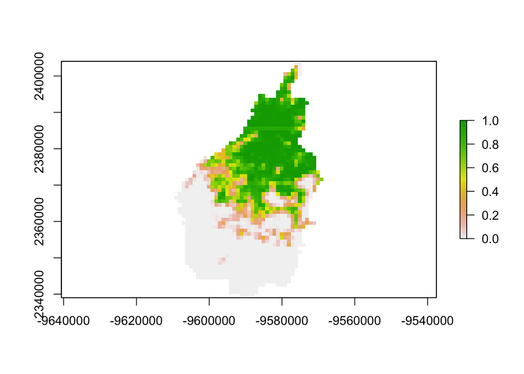

```r
built_up  <- raster('_input/cdmx_builtup.tif')
plot(built_up)
```

```r
population_data <- read.csv('_input/cdmx_population.csv')
head(population_data)
```

```
##   year population
## 1 1990    8695562
## 2 1991    8738833
## 3 1992    8772275
## 4 1993    8801777
## 5 1994    8828375
## 6 1995    8853087
```

## 3. Estimate the population distribution

Before allocating population we need to set a couple of parameters. First, we will define the population for the selected year. In this case, our year is 2014.

```r
population <- population_data[which(population_data$year == 2014), "population"]
population
```

```
## [1] 8874724
```

The second parameter is the total built-up fraction of our study area. This is —in simple terms, the sum all values in our built-up raster.

```r
total_builtup_fraction <- as.numeric(cellStats(x = built_up, stat = sum))
total_builtup_fraction
```

```
## [1] 567.001
```

The last step is quite straight-forward. We will use the **population** and the **total_builtup_fraction** as a transformation factor.

```r
population_raster <- built_up * (population / total_builtup_fraction)
```

## 4. Plot

Lastly, we will plot the final result using leaflet.

```r
pal <- colorNumeric(c("#556270", "#4ECDC4", "#C7F464", "#FF6B6B", "#C44D58"),
                    values(population_raster),
                    na.color = "transparent")

leaflet() %>%
  addProviderTiles(providers$OpenStreetMap.BlackAndWhite) %>%
  addRasterImage(population_raster, colors = pal, opacity = 0.5) %>%
  addLegend(pal = pal, values = values(population_raster),
    title = "Population (inhabitants)")
```

[interactive chart not shown]

## 5. Save your raster file

Save your raster file in your preferred directory.

```r
writeRaster(population_raster, filename = "_output/population_raster.tif", overwrite = TRUE)
```

That’s it!